# Loans_Default_Prediction_Shouvik

## Import Libraries

The libraries required for developing the classification model will be imported in this section.

```python
# Import baseline python libraries

import numpy as np
import pandas as pd
import warnings
warnings.filterwarnings('ignore')

# Import libraries for visualization

import matplotlib.pyplot as plt
import seaborn as sns
```

## Read Data

The data in the file"Data Set.csv" consists of data elements related to loan approval.

Data Dictionary for the data set for reference:

- BAD: 1 = Client defaulted on loan, 0 = loan repaid
- LOAN: Amount of loan approved.
- MORTDUE: Amount due on the existing mortgage.
- VALUE: Current value of the property.
- REASON: Reason for the loan request. (HomeImp = home improvement, DebtCon= debt consolidation which means taking out a new loan to pay off other liabilities and consumer debts)
- JOB: The type of job that loan applicant has such as manager, self, etc.
- YOJ: Years at present job.
- DEROG: Number of major derogatory reports (which indicates a serious delinquency or late payments).
- DELINQ: Number of delinquent credit lines (a line of credit becomes delinquent when a borrower does not make the minimum required payments 30 to 60 days past the day on which the payments were due).
- CLAGE: Age of the oldest credit line in months.
- NINQ: Number of recent credit inquiries.
- CLNO: Number of existing credit lines.
- DEBTINC: Debt-to-income ratio (all your monthly debt payments divided by your gross monthly income. This number is one way lenders measure your ability to manage the monthly payments to repay the money you plan to borrow.

```python
# Reading the data in python

raw_df = pd.read_csv('Data Set.csv')
```

```python
# Check if data loaded properly

raw_df.head()
```

|  | BAD | LOAN | MORTDUE | VALUE | REASON | JOB | YOJ | DEROG | DELINQ | CLAGE | NINQ | CLNO | DEBTINC |
| --- | --- | --- | --- | --- | --- | --- | --- | --- | --- | --- | --- | --- | --- |
| 0 | 1 | 1100 | 25860.0 | 39025.0 | HomeImp | Other | 10.5 | 0.0 | 0.0 | 94.366667 | 1.0 | 9.0 | NaN |
| 1 | 1 | 1300 | 70053.0 | 68400.0 | HomeImp | Other | 7.0 | 0.0 | 2.0 | 121.833333 | 0.0 | 14.0 | NaN |
| 2 | 1 | 1500 | 13500.0 | 16700.0 | HomeImp | Other | 4.0 | 0.0 | 0.0 | 149.466667 | 1.0 | 10.0 | NaN |
| 3 | 1 | 1500 | NaN | NaN | NaN | NaN | NaN | NaN | NaN | NaN | NaN | NaN | NaN |
| 4 | 0 | 1700 | 97800.0 | 112000.0 | HomeImp | Office | 3.0 | 0.0 | 0.0 | 93.333333 | 0.0 | 14.0 | NaN |

```python
# Checking if all records were read properly

raw_df.info()
```

```
<class 'pandas.core.frame.DataFrame'>
RangeIndex: 5960 entries, 0 to 5959
Data columns (total 13 columns):
 #   Column   Non-Null Count  Dtype
---  ------   --------------  -----
 0   BAD      5960 non-null   int64
 1   LOAN     5960 non-null   int64
 2   MORTDUE  5442 non-null   float64
 3   VALUE    5848 non-null   float64
 4   REASON   5708 non-null   object
 5   JOB      5681 non-null   object
 6   YOJ      5445 non-null   float64
 7   DEROG    5252 non-null   float64
 8   DELINQ   5380 non-null   float64
 9   CLAGE    5652 non-null   float64
 10  NINQ     5450 non-null   float64
 11  CLNO     5738 non-null   float64
 12  DEBTINC  4693 non-null   float64
dtypes: float64(9), int64(2), object(2)
memory usage: 605.4+ KB
```

```python
raw_df.describe(include = 'all').T
```

|  | count | unique | top | freq | mean | std | min | 25% | 50% | 75% | max |
| --- | --- | --- | --- | --- | --- | --- | --- | --- | --- | --- | --- |
| BAD | 5960 | NaN | NaN | NaN | 0.199497 | 0.399656 | 0 | 0 | 0 | 0 | 1 |
| LOAN | 5960 | NaN | NaN | NaN | 18608 | 11207.5 | 1100 | 11100 | 16300 | 23300 | 89900 |
| MORTDUE | 5442 | NaN | NaN | NaN | 73760.8 | 44457.6 | 2063 | 46276 | 65019 | 91488 | 399550 |
| VALUE | 5848 | NaN | NaN | NaN | 101776 | 57385.8 | 8000 | 66075.5 | 89235.5 | 119824 | 855909 |
| REASON | 5708 | 2 | DebtCon | 3928 | NaN | NaN | NaN | NaN | NaN | NaN | NaN |
| JOB | 5681 | 6 | Other | 2388 | NaN | NaN | NaN | NaN | NaN | NaN | NaN |
| YOJ | 5445 | NaN | NaN | NaN | 8.92227 | 7.57398 | 0 | 3 | 7 | 13 | 41 |
| DEROG | 5252 | NaN | NaN | NaN | 0.25457 | 0.846047 | 0 | 0 | 0 | 0 | 10 |
| DELINQ | 5380 | NaN | NaN | NaN | 0.449442 | 1.12727 | 0 | 0 | 0 | 0 | 15 |
| CLAGE | 5652 | NaN | NaN | NaN | 179.766 | 85.8101 | 0 | 115.117 | 173.467 | 231.562 | 1168.23 |
| NINQ | 5450 | NaN | NaN | NaN | 1.18606 | 1.72867 | 0 | 0 | 1 | 2 | 17 |
| CLNO | 5738 | NaN | NaN | NaN | 21.2961 | 10.1389 | 0 | 15 | 20 | 26 | 71 |
| DEBTINC | 4693 | NaN | NaN | NaN | 33.7799 | 8.60175 | 0.524499 | 29.14 | 34.8183 | 39.0031 | 203.312 |

## Exploratory Data Analysis

```python
# Checking quality of Data, whether missing values are present

raw_df.isna().sum()
```

```
BAD           0
LOAN          0
MORTDUE     518
VALUE       112
REASON      252
JOB         279
YOJ         515
DEROG       708
DELINQ      580
CLAGE       308
NINQ        510
CLNO        222
DEBTINC    1267
dtype: int64
```

```python
raw_df.count()
```

```
BAD        5960
LOAN       5960
MORTDUE    5442
VALUE      5848
REASON     5708
JOB        5681
YOJ        5445
DEROG      5252
DELINQ     5380
CLAGE      5652
NINQ       5450
CLNO       5738
DEBTINC    4693
dtype: int64
```

```python
len(raw_df)
```

```
5960
```

```python
#Creating df to analyze missing values

raw_df_dq = pd.DataFrame({'complete_values':raw_df.count(),
                          'missing_values': raw_df.isna().sum() })
```

```python
#Calculating %missing values
raw_df_dq['%missing'] = raw_df_dq['missing_values'].apply(lambda x : round((x / len(raw_df))*100,2))
```

```python
raw_df_dq
```

|  | complete_values | missing_values | %missing |
| --- | --- | --- | --- |
| BAD | 5960 | 0 | 0.00 |
| LOAN | 5960 | 0 | 0.00 |
| MORTDUE | 5442 | 518 | 8.69 |
| VALUE | 5848 | 112 | 1.88 |
| REASON | 5708 | 252 | 4.23 |
| JOB | 5681 | 279 | 4.68 |
| YOJ | 5445 | 515 | 8.64 |
| DEROG | 5252 | 708 | 11.88 |
| DELINQ | 5380 | 580 | 9.73 |
| CLAGE | 5652 | 308 | 5.17 |
| NINQ | 5450 | 510 | 8.56 |
| CLNO | 5738 | 222 | 3.72 |
| DEBTINC | 4693 | 1267 | 21.26 |

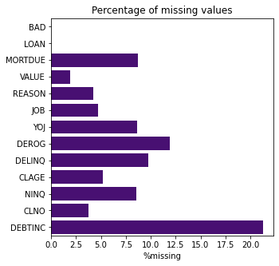

```python
plt.figure(figsize=(5,5))
plt.title('Percentage of missing values')
sns.barplot(x = '%missing',y=raw_df_dq.index, data=raw_df_dq, color= 'indigo')
```

```python
raw_df_dq.index
```

```
Index(['BAD', 'LOAN', 'MORTDUE', 'VALUE', 'REASON', 'JOB', 'YOJ', 'DEROG',
       'DELINQ', 'CLAGE', 'NINQ', 'CLNO', 'DEBTINC'],
      dtype='object')
```

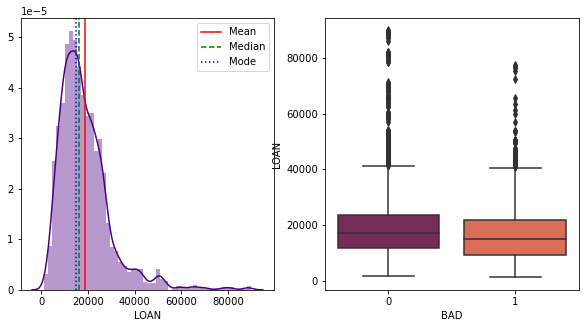

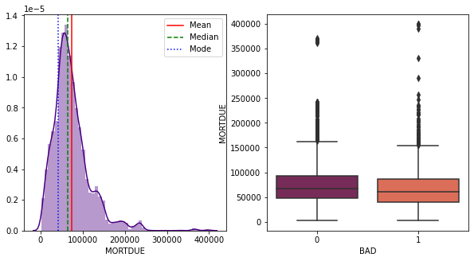

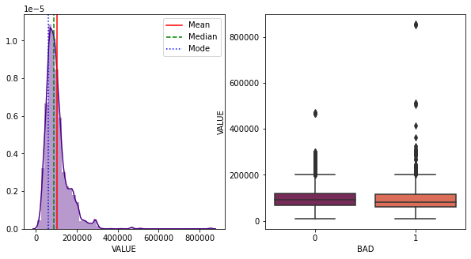

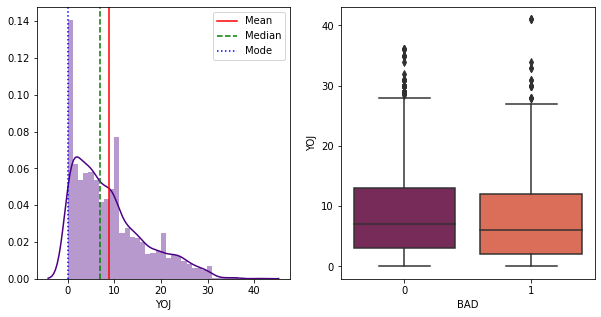

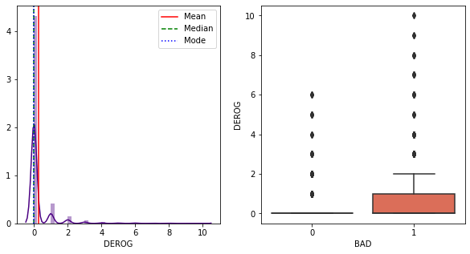

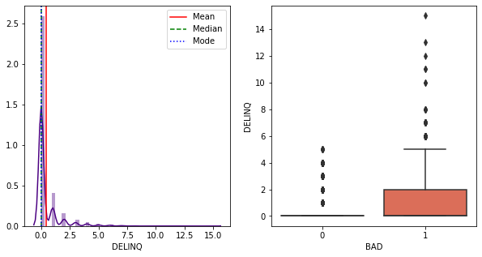

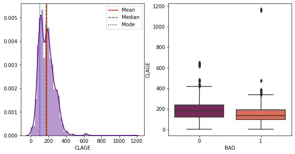

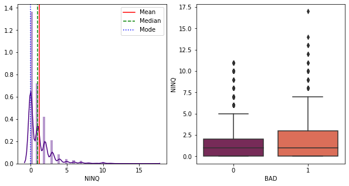

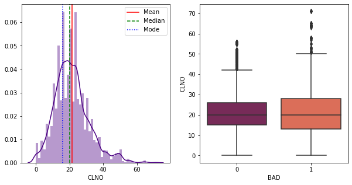

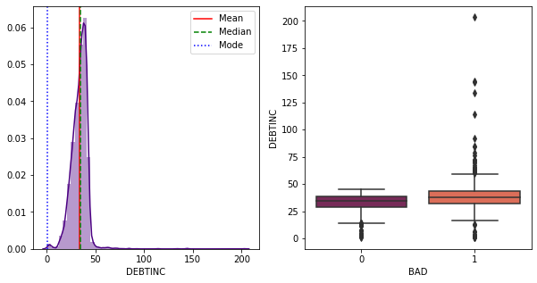

```python
#Analysis of numeric variables

for i in ['LOAN', 'MORTDUE', 'VALUE','YOJ', 'DEROG',
       'DELINQ', 'CLAGE', 'NINQ', 'CLNO', 'DEBTINC']:

    #Calculating mean, median & mode for the variables to plot
    mean=raw_df[i].mean()
    median=raw_df[i].median()
    mode=raw_df[i].mode()[0]

    plt.figure(figsize=(10,5))

    #Distplot to analyze the shape of the data
    plt.subplot(1, 2, 1)
    sns.distplot(raw_df[i],color= 'indigo',)
    plt.axvline(mean,color='r', linestyle='-')
    plt.axvline(median,color='g', linestyle='--')
    plt.axvline(mode,color='b', linestyle=':')
    plt.legend({'Mean':mean,'Median':median,'Mode':mode})

    #boxplot to analyze the outliers
    plt.subplot(1, 2, 2)
    bx = sns.boxplot(y=i,x='BAD',palette='rocket',data=raw_df)
    #plt.axhline(raw_df[i].mean(),color='r', linestyle='-')
    #plt.axvline(raw_df[i].median(),color='g', linestyle='--')
    #plt.axvline(raw_df[i].mode()[0],color='b', linestyle=':')
    plt.show()
```

### Insigts & Observations

1. Most of the independednt variables are right skewed.
2. Outliers exists however excpet of YOJ & CLAGE most of the other observations might be representative of real world scenario.
3. For YOJ, there are few observations which are greater than 30. We might consider them as outliers as this is generally not prevalent in current times.
4. For CLAGE, there are 2 observations greater than 1000 months ( approx 83 years). This is not usual we might consider them as outliers.
5. Defaulted loans (BAD = 1) has higher variance for DEROG & DELINQ variables. This might be an indication that customer with more deliquency reports and more delinquent credit lines are more likely to default the loans.

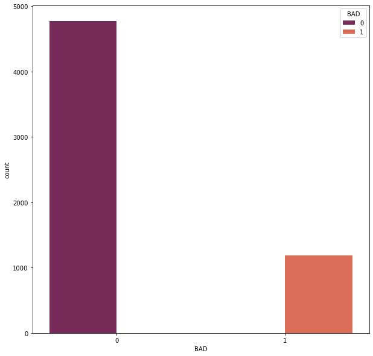

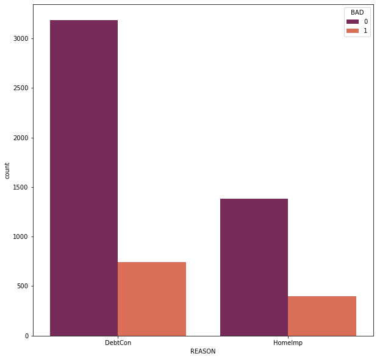

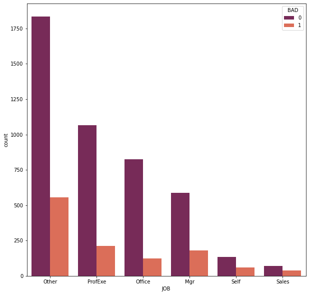

```python
#Univariate Analysis of categorical variables

for i in ['BAD', 'REASON', 'JOB']:
    plt.figure(figsize=(10,10))
    #Countplot to analyze the classes in the categorical variables
    sns.countplot(raw_df[i], order = raw_df[i].value_counts().index,palette='rocket',hue=raw_df['BAD'])
    plt.show()
```

### Insigts & Observations

1. Target variable 'BAD' is imbalanced.
2. Independent variables 'REASON' contains binary class, hence we can use label encoding during data preparation.
3. Independent variable 'JOB' is multiclass but not ordinal, hence we will use one hot encoding during data preparation.
4. JOB category 'Self' & 'Sales' have propotionaely higher defaulted loans when compared with all other JOB categories.

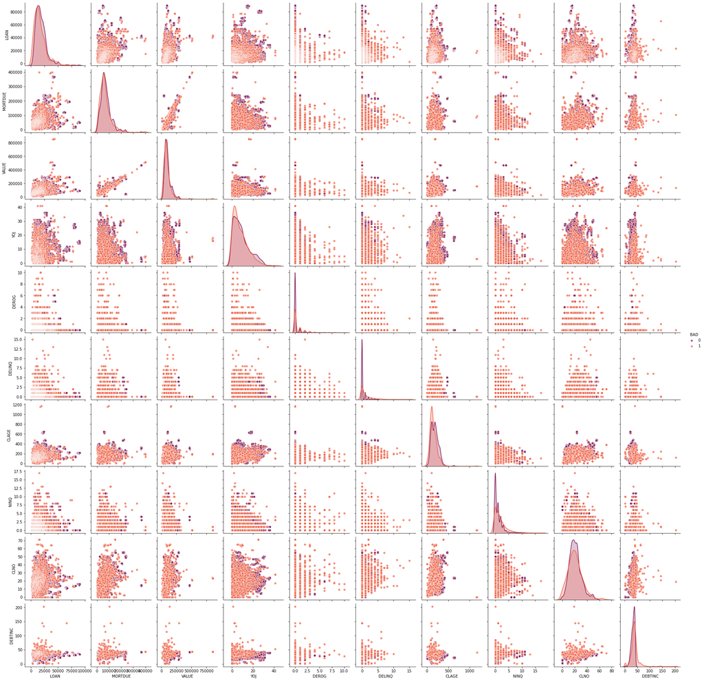

```python
#Multivariate analysis

sns.pairplot(data=raw_df,hue='BAD',palette='rocket',corner=False,
            plot_kws={'alpha': 0.7})
```

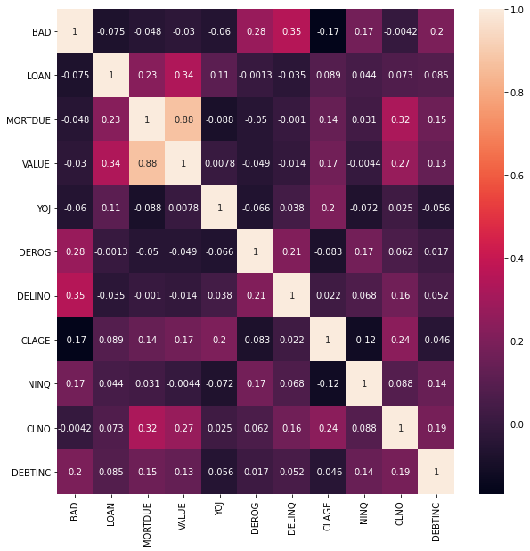

```python
#Checking corelation
plt.figure(figsize=(10,10))
sns.heatmap(raw_df.corr(),annot = True)
```

### Insights & Observation

1. There seems to be a stron co-linearity between VALUE & MORTDUE, we will evaluate to address this during model development.

```python
#Crosstab Analysis

#checking the mean values for defaulted and repaid loans
raw_df.groupby('BAD').mean()
```

| BAD | LOAN | MORTDUE | VALUE | YOJ | DEROG | DELINQ | CLAGE | NINQ | CLNO | DEBTINC |
| --- | --- | --- | --- | --- | --- | --- | --- | --- | --- | --- |
| 0 | 19028.107315 | 74829.249055 | 102595.921018 | 9.154941 | 0.134217 | 0.245133 | 187.002355 | 1.032749 | 21.317036 | 33.253129 |
| 1 | 16922.119428 | 69460.452973 | 98172.846227 | 8.027802 | 0.707804 | 1.229185 | 150.190183 | 1.782765 | 21.211268 | 39.387645 |

```python
#checking the mean values for defaulted and repaid loans
raw_df.groupby('BAD').median()
```

| BAD | LOAN | MORTDUE | VALUE | YOJ | DEROG | DELINQ | CLAGE | NINQ | CLNO | DEBTINC |
| --- | --- | --- | --- | --- | --- | --- | --- | --- | --- | --- |
| 0 | 16900 | 66839.0 | 90659.0 | 7.0 | 0.0 | 0.0 | 180.415787 | 1.0 | 20.0 | 34.541671 |
| 1 | 14900 | 60279.0 | 82000.0 | 6.0 | 0.0 | 0.0 | 132.866667 | 1.0 | 20.0 | 38.079762 |

```python
#analyzing JOB categories
pd.crosstab(raw_df['JOB'],raw_df['BAD'],normalize='index')
```

| BAD JOB | 0 | 1 |
| --- | --- | --- |
| Mgr | 0.766623 | 0.233377 |
| Office | 0.868143 | 0.131857 |
| Other | 0.768007 | 0.231993 |
| ProfExe | 0.833856 | 0.166144 |
| Sales | 0.651376 | 0.348624 |
| Self | 0.699482 | 0.300518 |

```python
#analyzing JOB categories
pd.crosstab(raw_df['JOB'],raw_df['BAD'],normalize='columns')
```

| BAD JOB | 0 | 1 |
| --- | --- | --- |
| Mgr | 0.130233 | 0.153516 |
| Office | 0.182281 | 0.107204 |
| Other | 0.406202 | 0.475129 |
| ProfExe | 0.235659 | 0.181818 |
| Sales | 0.015725 | 0.032590 |
| Self | 0.029900 | 0.049743 |

```python
#analyzing REASON categories
pd.crosstab(raw_df['REASON'],raw_df['BAD'],normalize='index')
```

| BAD REASON | 0 | 1 |
| --- | --- | --- |
| DebtCon | 0.810336 | 0.189664 |
| HomeImp | 0.777528 | 0.222472 |

```python
#analyzing REASON categories
pd.crosstab(raw_df['REASON'],raw_df['BAD'],normalize='columns')
```

| BAD REASON | 0 | 1 |
| --- | --- | --- |
| DebtCon | 0.696956 | 0.652936 |
| HomeImp | 0.303044 | 0.347064 |